# Synthetic Data Generation for Economic Policymaking

IndabaX Ghana 2026 Theory Session | Sponsored by ACET

Austin Denteh  
Prince Baah  
Blaise Bayuo

June 24, 2026

# Introductions

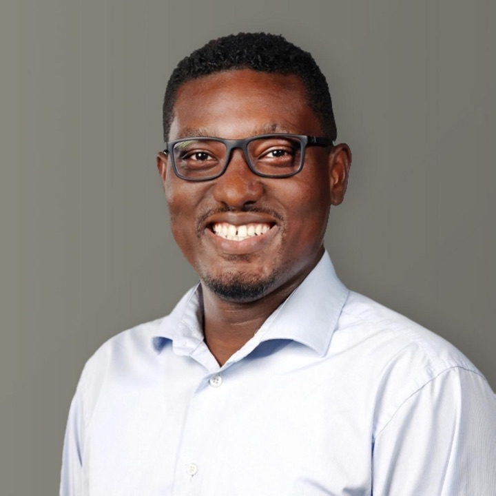

Austin Denteh

Department of Economics, Davidson College; Co-founder, Ghana Data Science Summit (IndabaX Ghana)

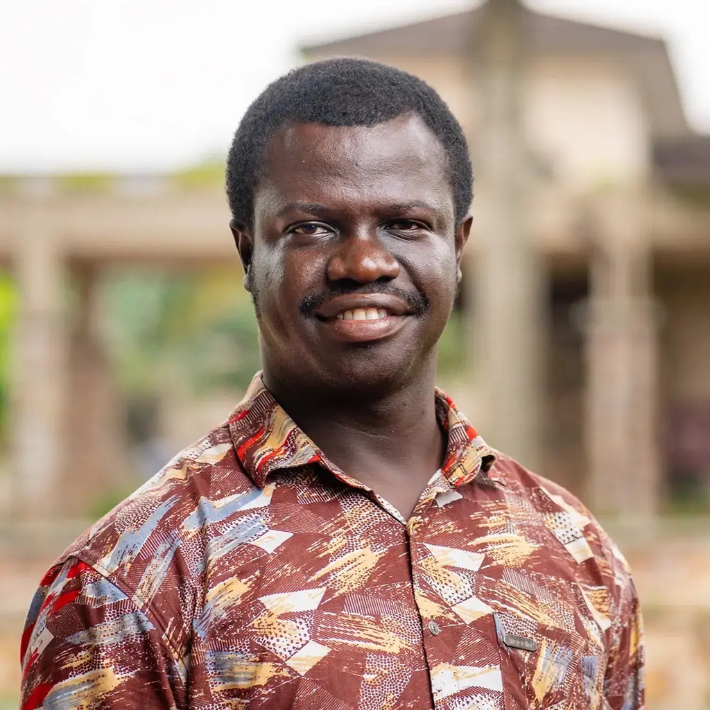

Prince Baah

Lecturer, Department of Economics, Ashesi University

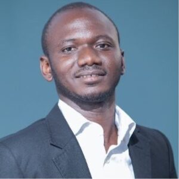

Blaise Bayuo

Senior Fellow, African Center for Economic Transformation

# Learning objectives

1. classify a synthetic data design by what is observed, missing, and generated
2. write the synthetic data generation problem as $p(Y \mid X)$
3. generate multiple synthetic imputed datasets and analyze them
4. validate synthetic data with holdout data transportability checks
5. explain when synthetic data evidence is useful, limited, or not credible

# Basic prerequisites

Minimum prerequisites includes:

- basic R literacy: run a script, edit a variable name, etc
- comfort with household survey concepts
- regression fundamentals: predictions depend on predictors
- willingness to critically assess model output

Let’s get to know you

Answer these background questions so we all get to know each other.

# Datasets have their own strengths/weaknesses

- Have you ever tried to do a project and realize your data set is missing a **key variable**?
  - Moreover, that variable may be available in a different data set!
- **Can synthetic data help us combine complementary surveys for policy analysis?**
- We will introduce you to two surveys in this tutorial
  1. GLSS is strong on consumption-based welfare aggregates, poverty, and expenditure
  2. DHS is strong on health, fertility, nutrition, and household conditions.

# Our two data sources: GLSS and DHS

|  | GLSS | DHS |
| --- | --- | --- |
| What it is | Ghana Living Standards Survey | Demographic and Health Survey |
| Who runs it | Ghana Statistical Service | GSS, with health-sector partners and DHS Program support |
| Focus | Consumption, expenditure, income; official poverty statistics | Fertility, child health, nutrition, mortality, housing |
| Rounds | GLSS1 1987/88 to GLSS7 2016/17 | 1988 to 2022, roughly every five years |

# Examples of DHS 2014 variables

| Role | DHS 2014 examples |
| --- | --- |
| Analysis outcomes | stunting/anthropometry, anemia, fever, diarrhea, cough, vaccination |
| Shared predictors $X$ | region, urban/rural, household size, head age/sex, education, assets, electricity, water, toilet, cooking fuel, housing |

- **What the DHS 2014 lacks:** consumption-based welfare aggregate, consumption, poverty status.
- We will call these “missing” variables the synthetic targets $Y$

# Examples of GLSS6 variables

| Role | GLSS6 examples |
| --- | --- |
| Synthetic targets $Y$ | welfare aggregate, poverty status, total/food/non-food expenditure, health spending |
| Shared predictors $X$ | region, urban/rural, household size, education, housing, water, toilet, electricity, cooking fuel |

- **What the GLSS6 is missing:** child anthropometry outcomes (e.g., stunting), anemia, illness, and vaccination.
- We will call these the analysis/policy outcomes

# GLSS6 vs DHS 2014

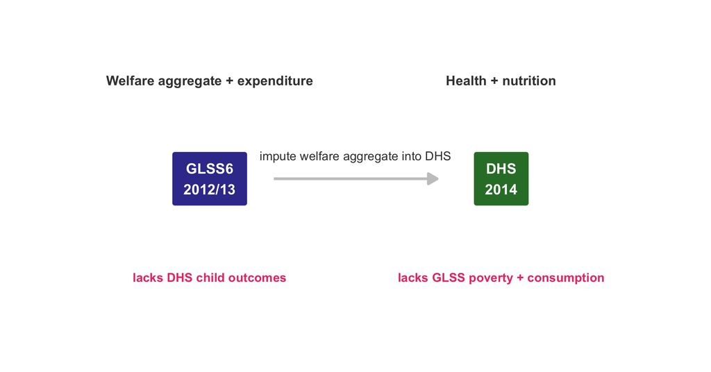

# Running question for today (need both surveys)

- **Running question: What share of children are stunted in poor vs. non-poor households, using Ghana’s official consumption-based poverty line?**
- In DHS, `stunted = 1` means the child’s height-for-age z-score is below -2
  - In our DHS teaching extract, the weighted stunting rate is **17.9%**
  - DHS has stunting but no consumption-based poverty line
- GLSS6 has the official poverty line but no stunting
- Synthetic data generation lets DHS borrow poverty status from GLSS

# Prediction before we impute poverty

In our DHS teaching extract, the weighted stunting rate is **17.9%**.

**Once we impute consumption-based poverty, should stunting be higher among poor households?**

# Three variable groups drive the running question

| Group | Variable in the tutorial | How to read it |
| --- | --- | --- |
| Shared predictors $X$ | `region10`, `urban`, household traits | observed in both surveys |
| Synthetic target $Y$ | welfare aggregate (`welfare`) | real consumption/expenditure per adult equivalent in GLSS6, imputed into DHS |
| Analysis outcome | `stunted` | a DHS child indicator based on height-for-age |

# The welfare aggregate is constructed

- GLSS asks many food and non-food consumption/expenditure questions.
- The GLSS poverty aggregate file combines those items into a real living standard measure.
- In this tutorial, `welfare` is **annual Ghana cedis per adult equivalent**, in 2013 prices.
- It is not household income, and it is not the DHS asset-based wealth index.

# From the welfare aggregate to poverty

Poverty status is **not** imputed. It is a deterministic rule applied to each drawn consumption-based welfare aggregate (`welfare`):
$$\text{poverty status} =
\begin{cases}
\text{very poor} & \text{welfare agg.} < 792 \\
\text{poor} & 792 \le \text{welfare agg.} < 1{,}314 \\
\text{non-poor} & \text{welfare agg.} \ge 1{,}314
\end{cases}
\quad (\text{GH\textcent/adult eq.})$$

# Think–pair–share: printed worksheet, Part A

- **Write one question** you could *only* answer by combining both surveys—name the DHS outcome and the GLSS-only variable it needs.
- Then, write the role for each variable in the blank column (on worksheet)

| Role | What it means (not the answer) |
| --- | --- |
| Predictors $X$ | observed in both surveys |
| Targets $Y$ | observed in GLSS only; what we generate for DHS |
| Outcomes | DHS child outcomes studied after synthetic data generation |

# Another motivation: survey data between waves

- **GHAMOD** is Ghana’s tax-benefit microsimulation model, part of UNU-WIDER’s SOUTHMOD family.
- It applies Ghana’s tax and benefit rules—income taxes, VAT, LEAP transfers—to GLSS household microdata, household by household, to evaluate reforms before they happen.
- Policy rules are updated every year, but recent GLSS rounds arrive only **every four to seven years** — so reforms get simulated on an aging population.
- Synthetic data is used to generate a current-year baseline between survey waves.

# Synthetic data is a missing data framework

- We are in search of a model as follows:
  $$\underbrace{Y^{mis} \sim p(Y \mid X, \theta)}_{\text{generate for DHS
  households}}, \qquad \underbrace{\theta \sim p(\theta \mid Y^{obs},
  X)}_{\text{learned entirely in GLSS}}$$
- $p(\cdot)$ means a **probability model**: it gives a distribution of possible welfare aggregate values for households with $X$.
- We learn the relationship from GLSS, where $\theta$ comes from
- We then **transport** it to DHS: plug each DHS household’s $X$ into the fitted model and draw its missing synthetic targets $Y$

# We model columns in GLSS, then fill them in DHS

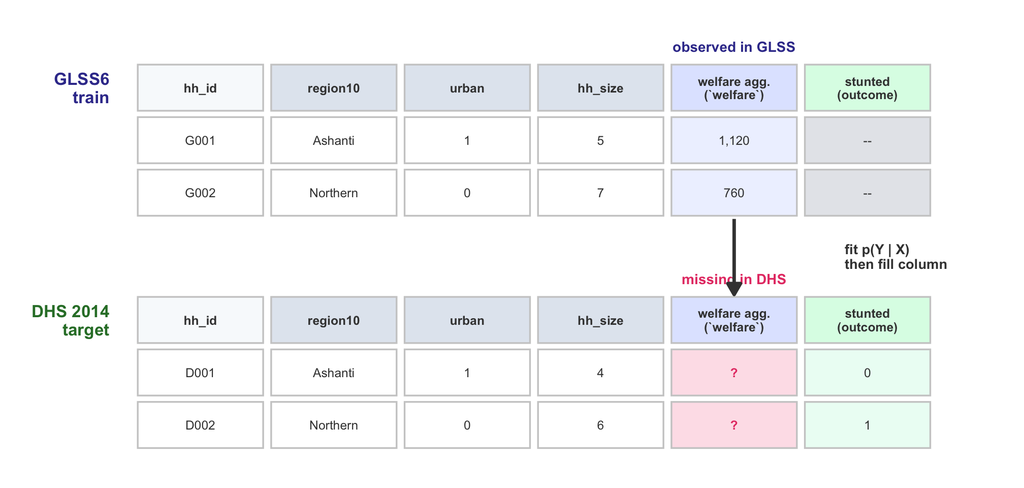

# Step 1: Choose a data set to build the model on

- We build the model on a **GLSS6**: a harmonized extract of households carrying the synthetic targets $Y$ plus the shared predictors $X$
- We need to recode the shared predictors to common categories
- GLSS6 is the estimation sample ($X$ and $Y$ observed)
- DHS 2014 supplies the records (households) to be completed (with only $X$)

# Step 2: We create partially synthetic data

- We model only the imputed block, conditional on the shared predictors, as a chain of conditional marginals (sequential regression):
  $$p(Y_1, \ldots, Y_K \mid X) = p(Y_1 \mid X)\, p(Y_2 \mid X, Y_1) \cdots
  p(Y_K \mid X, Y_1, \ldots, Y_{K-1})$$
- **Partially synthetic:** each DHS record keeps its real $X$; only the GLSS-only synthetic target $Y$ block is generated.
- Within the block, the chain models the joint distribution: each draw conditions on earlier draws
- See the appendix for fully synthetic data case.

# Activity: Derive the model (worksheet Part B)

**Your task:** Derive the joint model of the two synthetic targets $Y$ — **log welfare aggregate (`log(welfare)`)** and **NHIS registration** — into a chain of draws conditional on the shared predictors $X$.

$$p(\log(\text{welfare}),\ \text{NHIS} \mid X) \;=\; \rule{2.5cm}{0.4pt}$$

# Begin with single imputation

Start with a **single** imputation — one completed dataset:

1. Fit the model of $Y$ on $X$ in GLSS (e.g., a regression for log welfare aggregate).
2. **Draw the parameters** $\theta$ from their estimated distribution
3. **Draw a value** $Y^{mis}$ for each DHS household from $p(Y \mid X, \theta)$.

That gives **one imputed dataset** (sometimes called an implicate): real $X$, synthetic $Y$.

**But a single draw hides its own uncertainty — so we do not stop at one.**

# The imputation workflow at a glance

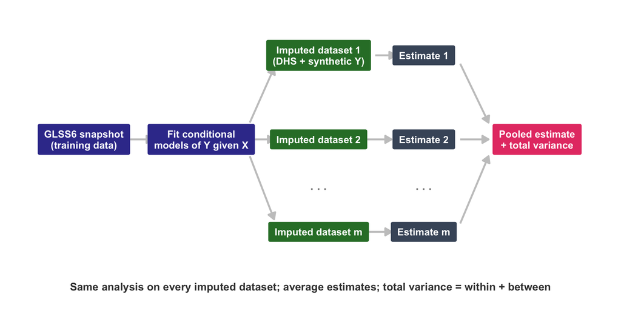

# Multiple imputation keeps uncertainty visible

- **Multiple imputation** (Rubin 1987): repeat the single-imputation draw several times, creating multiple completed copies of the data (**imputed datasets**), each with its own drawn values.
- Why not impute once? A single imputation hides the extra variability the imputation introduces — confidence intervals come out too small, and parameters look significant too often.
- Run the same standard analysis on each imputed dataset, then combine:
  - average the point estimates
  - total variance = within-imputation variance + between-imputation variance
- Never report results from a single imputed dataset.

# Multiple imputation means multiple completed DHS copies

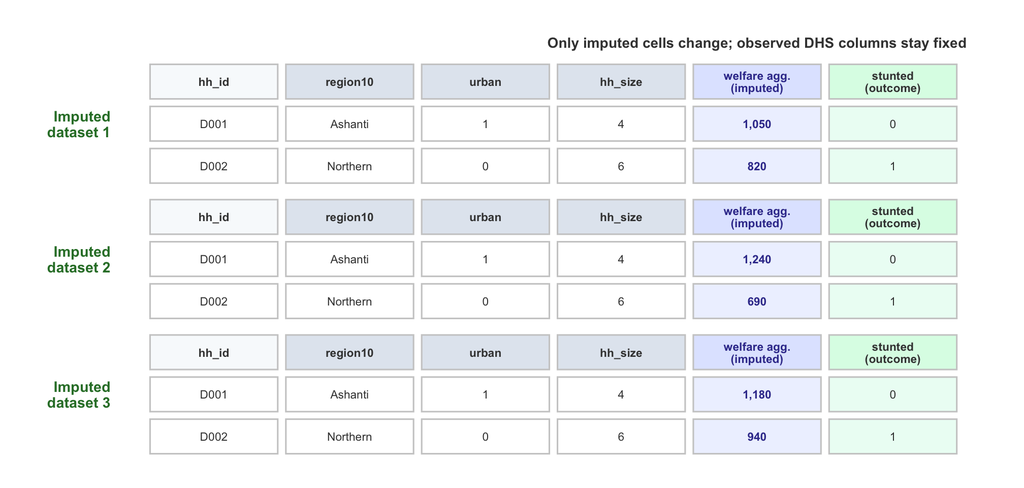

# Decisions for every imputed variable

1. **Model type** — parametric regression, logistic regression, CART, or hot-deck / predictive mean matching, etc.
2. **Restrictions on values** — keep expenditures non-negative; derive poverty status from the drawn welfare aggregate at the official poverty lines; structural zeros stay zero (e.g. education spending in a household with no one enrolled in school)

# Two validation checks

We build in **two** ways to test our synthetic data model:

1. **GLSS holdout**: can the model recover the synthetic targets $Y$ where we already know it?
2. **Transport check** — does a GLSS relationship still hold in DHS?

# Validation Check 1 — GLSS holdout

- We hold out a slice of GLSS6 households **before** fitting.
- The synthetic targets $Y$ (e.g., the welfare aggregate) is not observed in DHS
  - the holdout is the only place generated welfare aggregate values can be checked against ground truth.
- Fit on the rest, predict the held-out households, compare to their **true** welfare aggregate.

# Validation Check 2 — transport

- Here we meet a fourth type of variable: a validation target: a shared variable DHS and GLSS *both* observe (e.g., electricity)
- Pretend DHS lacks it, predict it from GLSS, then compare to what DHS actually recorded.
- This tests whether the relationship hold across surveys (transport) for an observed variable
  - In the synthetic data literature this is called *calibration*

# Summary of validation checks

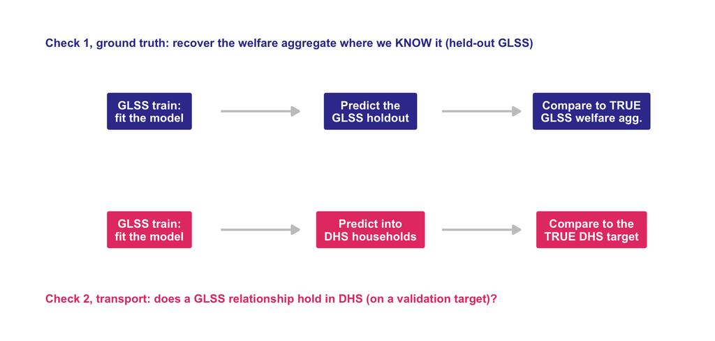

# Judging usefulness of synthetic data

We will ask whether the synthetic data preserve:

- the welfare aggregate distribution in a GLSS holdout
- subgroup patterns across region and urban/rural status
- validation targets the model did not train on
- the final child-outcome gradient by synthetic poverty status

# Pros and Cons of synthetic data

- Advantages of synthetic data
  - It can help analysts reason between survey waves.
  - It can support scenario analysis and model stress tests.
- Synthetic data can fail when:
  - the two surveys measure similar concepts differently
  - important variables are omitted
  - relationships differ across the GLSS and DHS samples

# Transition to hands-on session

1. **Set up** — inspect the harmonized GLSS/DHS surfaces; define the welfare aggregate (continuous), derived poverty status, NHIS registration (binary), and the shared predictors.
2. **Split** — 80/20 region-stratified GLSS holdout, fixed seed.
3. **Fit** — the imputation model in GLSS, with household weights.
4. **Check twice** — welfare aggregate vs. ground truth on the holdout; one validation target into DHS.
5. **Enrich** — impute the welfare aggregate into DHS, $m = 5$ imputed datasets.
6. **Analyze and pool** — child outcomes by synthetic poverty status; Rubin within + between variance.

# Setting up your computer

1. Download/clone the public GitHub repo and open that folder.
2. Install **R**, **RStudio**, and these R packages:

```r
install.packages(c("mice", "dplyr", "ggplot2",
                   "rmarkdown", "kableExtra", "tidyr"))
```

3. During the practical, download `acet-indabax-2026-local-data.zip` from the README Dropbox link.
4. Unzip it at the repo root so the files land in `data/practical/teaching/`.
5. Open the practical `.Rmd` notebook. Prefer line-by-line code? Open the generated `.R` script.
6. No local setup? Use the WebR HTML file in `webr/`.

# Backup

# Backup: Other use cases fit the same logic

- **Between-wave GLSS updating:** generate plausible policy-year baselines for GHAMOD-style microsimulation.
- **Crisis simulation:** stress-test social protection systems under income or price shocks.
- **Small-area analysis:** generate plausible local estimates when samples are thin.
- **Privacy-preserving access:** release synthetic microdata when raw records cannot be shared.

# Backup: Partially synthetic and fully synthetic differ

| Type | What is replaced? | Typical purpose |
| --- | --- | --- |
| Partially synthetic | Sensitive variables or records | Reduce disclosure risk while preserving structure |
| Fully synthetic | All values are generated | Broader release or model-based simulation |

# Backup: The fully synthetic model

Fully synthetic data models the entire joint distribution — predictors included:

$$p(Y_1, \ldots, Y_K) = p(Y_1)\, p(Y_2 \mid Y_1) \cdots p(Y_K \mid Y_1,
\ldots, Y_{K-1})$$

- Whole records are drawn from the model; no released value is an observed response (the privacy use case).
- Our enrichment needs only the conditional block $p(Y \mid X)$, because DHS supplies real $X$ — that is what makes it partially synthetic.
- *One nuance:* classic partially synthetic data replaces observed sensitive values; we generate values DHS never measured — same machinery, different purpose.

back to Step 2

# Backup: The SIPP Synthetic Beta is the canonical public example

- The Census Bureau created synthetic SIPP data linked to administrative earnings and benefits.
- Researchers can analyze synthetic files, then request validation against confidential “gold standard” data.
- The key lesson is institutional: synthetic data works best with a validation service and feedback loop.

# Backup: Combining estimates across imputed datasets

For $m$ imputed datasets with estimates $q^{(i)}$ and variances $u^{(i)}$, Rubin’s rules (what `mice` uses) give:

$$\bar{q} = \frac{1}{m}\sum_i q^{(i)}, \qquad \bar{u} = \frac{1}{m}\sum_i
u^{(i)}, \qquad b = \frac{1}{m-1}\sum_i \left(q^{(i)} - \bar{q}\right)^2$$

$$T = \bar{u} + \left(1 + \tfrac{1}{m}\right) b$$

- $\bar{u}$ is the average within-imputation variance; $b$ is the between-imputation variance.
- Fully synthetic replicates use a different total-variance formula (Reiter 2004), as in the SSB.

# Backup: pMSE is a one-number utility check

- Stack real and synthetic records; create an indicator equal to 1 for synthetic rows.
- Fit a logistic regression of the indicator on the variables; pMSE is the mean squared deviation of the predicted probabilities from 0.5.
- If the model cannot separate real from synthetic, predictions sit near 0.5; the utility score $1 - \frac{pMSE}{0.25}$ runs from 0 (worst) to 1 (best).

# Backup: The strongest critique is about joint distributions

Recent critiques of fully synthetic census microdata warn that realistic marginals do not guarantee realistic relationships.

**Practical implication:** our DHS enrichment validation should test the relationships that matter for policy, not just the variables that are easiest to plot.

# Backup: References for deeper reading

- Rubin (1987): multiple imputation for nonresponse in surveys.
- Rubin (1993), Little (1993): synthetic data as multiple imputation.
- Benedetto, Stanley, and Totty (2018): SIPP Synthetic Beta.
- Jarmin, Louis, and Miranda: synthetic data at the U.S. Census Bureau.
- Freiman et al.: formal privacy and ACS synthetic data.
- Ruggles (2025): critique of fully synthetic census microdata.
- Adu-Ababio et al. (2023): GHAMOD v2.6 country report.